# Spatial Map

### Section 8.3: Visualize the n-dimensional spatial map

- each dimension represents a different variable, such as position, travel direction, and trial number
- we can use that to plot the ratemaps for each trial number and travel direction

```python
unit_id = 9  # choose a unit to visualize
fig, ax = plt.subplots(
    2, 2, sharey="row", sharex=True, gridspec_kw={"height_ratios": [1, 3]}
)

extent = [
    spatial_map.bin_centers[0].min(),
    spatial_map.bin_centers[0].max(),
    spatial_map.bin_centers[2].min(),
    spatial_map.bin_centers[2].max(),
]
npy.plotting.plot_peth_fast(
    spatial_map.ratemap[unit_id, :, 0, :],
    spatial_map.bin_centers[0],
    estimator=np.nanmean,
    ax=ax[0, 0],
)

ax[1, 0].imshow(
    spatial_map.ratemap[unit_id, :, 0, :].T,
    interpolation=None,
    aspect="auto",
    extent=extent,
    vmin=0,
    vmax=np.nanmax(spatial_map.ratemap[unit_id, :, :, :]),
    origin="lower",
)

npy.plotting.plot_peth_fast(
    spatial_map.ratemap[unit_id, :, 1, :],
    spatial_map.bin_centers[0],
    estimator=np.nanmean,
    ax=ax[0, 1],
)

ax[1, 1].imshow(
    spatial_map.ratemap[unit_id, :, 1, :].T,
    interpolation=None,
    aspect="auto",
    extent=extent,
    vmin=0,
    vmax=np.nanmax(spatial_map.ratemap[unit_id, :, :, :]),
    origin="lower",
)
ax[0, 0].set_title("Outbound")
ax[0, 1].set_title("Inbound")
ax[1, 0].set_ylabel("Trial number")
ax[1, 0].set_xlabel("Position (cm)")
ax[1, 1].set_xlabel("Position (cm)")
ax[0, 0].set_ylabel("Rate (Hz)")
sns.despine()
```

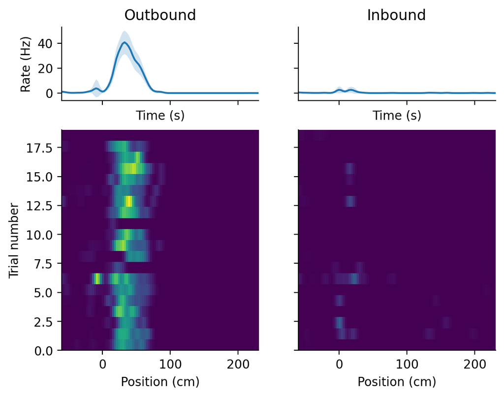